# Neural Networks

Session 3: Perceptrons, Backprop & CNNs

David Picard

2026-10-19

# Welcome

## Session 3: Agenda

8:30–11:30 · 180 min

| Time | Block |
| --- | --- |
| 8:30–8:32 | Recap: where we left off |
| 8:32–8:42 | Biology of a neuron |
| 8:42–8:45 | McCulloch-Pitts formal neuron |
| 8:45–9:00 | Perceptron: circuits, Hebbian rule, history & modern view |
| 9:00–9:05 | Impossibility theorem (XOR) |
| 9:05–9:15 | MLP & activation functions |
| 9:15–9:25 | ⚡ Exercise: XOR by hand |
| 9:25–9:40 | Backprop: Leibniz notation → MLP equations → vanishing/exploding |
| 9:40–9:45 | XOR with backprop |
| 9:45–10:00 | ☕ Break |
| 10:00–10:20 | Universal approximation theorem |
| 10:20–10:45 | Convolutions: equivariance, 1D & 2D |
| 10:45–10:55 | ⚡ Exercise: convolution and finite signals |
| 10:55–11:10 | History: LeNet → AlexNet → VGG |
| 11:10–11:25 | ResNet, residual connections & loss landscape |
| 11:25–11:30 | Wrap-up |

## Where we left off

- Session 2: generalized linear models, regularization, SVM, kernels
- Everything so far has been **one layer** of parameters
- Today: stack layers, let the network **learn its own features**

# Biology, Formal Neuron & Perceptron

0:00–0:35 · 35 min

## Biological neuron

[interactive chart not shown]

*Signals are recorded as spike trains. Enough trains trigger the neuron to launch its own spikes*

## Firing := Electric wave

[interactive chart not shown]

*Threshold based ion channels create avalanche effects in difference of potential that travels like a wave*

## From biology to a formal model

- Many inputs (dendrites) → accumulated signal → one all-or-nothing output (axon)
- Some inputs excite, some inhibit, and not all synapses carry the same strength
- McCulloch & Pitts (1943): symbolic logic (no notion of learning)

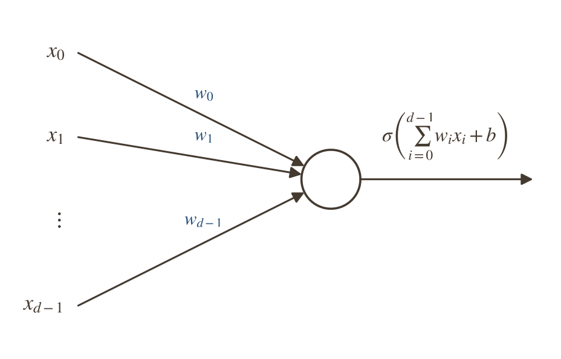

The formal neuron: a weighted sum of the inputs $x_0,\dots,x_{d-1}$ plus a bias $b$, passed through an activation function $\sigma$.

## McCulloch-Pitts formal neuron

$$h(x) = \sigma(\langle w, x\rangle + b)$$

- $x$: inputs, $w$: synaptic strengths, $b$: firing threshold, $\sigma$: a thresholding function
- Originally: $x \in \{0,1\}^d$, $= $ step function, “activated or not”
- The $\sigma(\langle w,x\rangle + b)$ formula is not explicitly in the 1943 paper → modern restatement of it

## A bit of history

- McCulloch & Pitts worked in **boolean algebra**, not vector spaces
- Their research: which boolean functions can networks of such neurons compute, depending on whether the network has cycles?
- This is the root of what became **symbolic AI**: logic circuits made of neurons, decades before gradient descent optimization

## The Perceptron

- Rosenblatt (1958): the first neural network, built first and foremost as **hardware**
- Several output units, linked by **inhibition** so only one fires at a time
- No gradient descent: *handcrafted update rules* for the circuit’s wiring

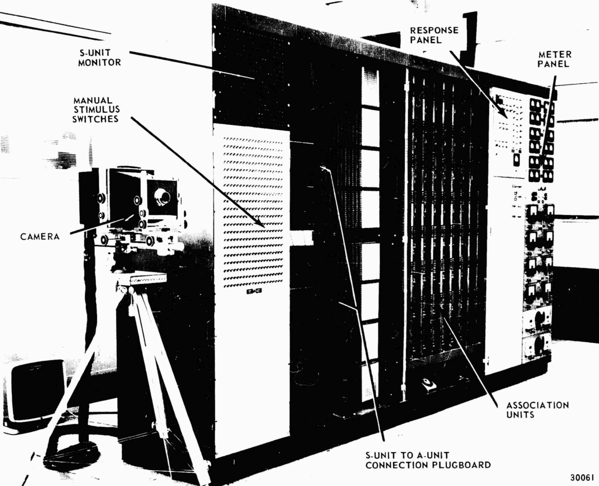

From the Perceptron’s manual (public domain)

## The perceptron as a logic gate

[interactive chart not shown]

*AND, OR, NAND: a single hyperplane cutting $\{0,1\}^2$. Neuron: a logic gate for a suitable choice of weights.*

## Hebbian learning

- Hebb (psychologist): “cells that fire together, wire together”
- Rosenblatt’s unsupervised update: strengthen a weight whenever *both* its input and its output are active
  $$w_i \leftarrow w_i + \eta\, x_i\, y$$
- Purely local, no notion of a target label, reinforces co-activation

## Supervised learning

- To get supervised learning, Rosenblatt’s Perceptron needed an **operator** to manually force an output and trigger reinforcement
- Modern terminology: the Perceptron is a **linear model with a differentiable $\sigma$, trained by gradient descent**

## Impossibility theorem

**Perceptron impossibility.** There exists a distribution on $(x \in \mathbb{R}^d, y\in\{0,1\})$ that cannot be learned by any predictor $h(x) = \sigma(w^\top x + b)$ with $\sigma$ strictly increasing.

## Proof

The counter-example is XOR: $(0,0)\mapsto 0,\ (1,1)\mapsto 0,\ (0,1)\mapsto 1,\ (1,0)\mapsto 1$

Let $\theta$ be the unique threshold such that $\sigma(\theta) > k$ reads as output $1$. Solving XOR would require all four of
$$b \leq \theta,\\ \quad w_2+b > \theta,\\ \quad w_1+b > \theta,\\ \quad w_1+w_2+b
\leq \theta$$
Summing equations 1 and 4 gives $w_1+w_2+2b \leq 2\theta$. Summing 2 and 3 gives $w_1+w_2+2b > 2\theta$. Contradiction.

## XOR and Perceptron

[interactive chart not shown]

# Multi-Layer Perceptrons & Backpropagation

0:35–0:45 · 10 min

## Multi-layer perceptron

- Like kernels: map the input through a non-linearity, hope the result is linearly separable
- Instead of a *fixed* non-linear map $\phi$, **learn** it by stacking perceptrons on top of each other

$$f_i(x) = \big[\sigma(w_{ij}^\top x + b_{ij})\big]_{j \leq d_i}, \qquad
F(x) = f_L \circ \cdots \circ f_1(x)$$

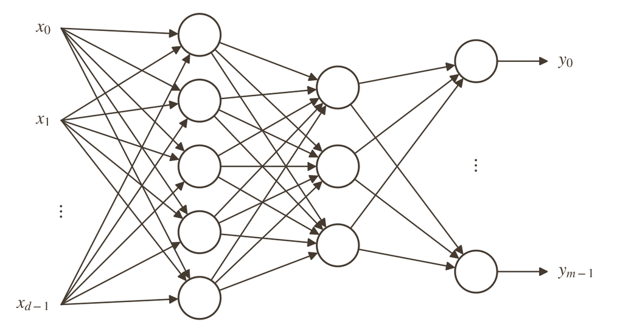

A multilayer perceptron: input $x$ through 3 fully-connected layers.

## Activation functions

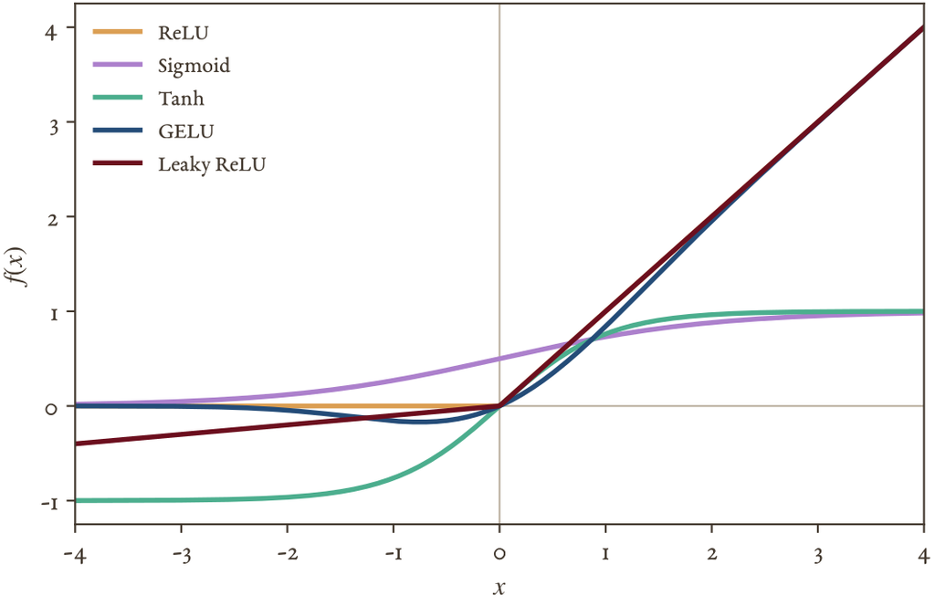

Sigmoid, tanh, ReLU, Leaky ReLU, GeLU

- **Sigmoid** $\frac{1}{1+e^{-x}}$: range $(0,1)$, saturates both ends (flat gradient, hurts training)
- **tanh**: range $(-1,1)$, same saturation issue, wider range
- **ReLU** $\max(0,x)$: gradient is $1$ on the right, but **dead units** on the left (zero gradient forever)
- **Leaky ReLU**: small slope $\alpha$ on the left, no dead units
- **GeLU** $x\,\Phi(x)$: smooth everywhere, gradient vanishes only where it should

# Exercise: XOR by Hand

0:45–0:55 · 10 min

## ⚡ Solve XOR with 2 hidden neurons

Using a **single hidden layer with only 2 neurons**, equipped with the $\mathrm{sign}$ activation, compute by hand weights that solve XOR.

# Backpropagation

0:55–1:15 · 20 min

## MLP training: ERM

$$\hat{\mathcal{R}}_{\mathcal{A}}(F) = \frac1n \sum_{i=1}^n \ell(y_i, F(x_i))$$

- Minimize over every layer’s weights $w_1, \ldots, w_L$ by gradient descent, estimated on mini-batches
- Need $\frac{\partial \ell}{\partial w_l}$ for every layer $l$: **chain rule** through a composition of $L$ functions

## Chain of neuron

Simplify to a chain of scalar neurons, $x_0 \to x_1 \to x_2 \to \ell$, with $x_k = \sigma(w_k x_{k-1})$:
$$x_1 = \sigma(w_1 x_0), \qquad x_2 = \sigma(w_2 x_1), \qquad \ell = \ell(y, x_2)$$

Leibniz notation makes every intermediate variable explicit

## Leibniz notation

$$\frac{\partial \ell}{\partial w_2} = \frac{\partial \ell}{\partial x_2}\cdot
\frac{\partial x_2}{\partial w_2}
= \ell'(y,x_2)\cdot \sigma'(w_2 x_1)\, x_1$$

$$\frac{\partial \ell}{\partial w_1} = \frac{\partial \ell}{\partial x_2}\cdot
\frac{\partial x_2}{\partial x_1}\cdot \frac{\partial x_1}{\partial w_1}
= \underbrace{\ell'(y,x_2)\,\sigma'(w_2 x_1)}_{\text{reused from above}}
\cdot\ w_2\, \sigma'(w_1 x_0)\, x_0$$

- The term under the brace is re-used (only one computation)

## Backpropagating gradients: $\delta$

Define $\delta_2 = \ell'(y,x_2)\,\sigma'(w_2 x_1)$ (the “local gradient” at neuron 2)

$\delta_1 = \delta_2\, w_2\, \sigma'(w_1 x_0)$. Then

$$\frac{\partial \ell}{\partial w_2} = \delta_2\, x_1, \qquad
\frac{\partial \ell}{\partial w_1} = \delta_1\, x_0$$

- $\delta$ propagates **backward**, each step multiplying by that layer’s own local derivative

## Backprop for MLP

Same recursion
$$\delta_L = \ell'(y, F(x)) \circ \sigma'(x_L), \qquad
\delta_k = w_{k+1}^\top\big(\sigma'(x_{k+1}) \circ \delta_{k+1}\big)$$
$$\frac{\partial \ell}{\partial w_k} = \delta_k\, x_{k-1}^\top, \qquad
\frac{\partial \ell}{\partial b_k} = \delta_k$$

- $\circ$: element-wise product. $x_k$: layer $k$’s output, stored during the forward pass
- Forward pass computes and stores every $x_k$; backward pass computes every $\delta_k$ from $L$ down to $1$, reusing the previous step

## Backprop is cheap

- Back-propagation costs at most **3x** the forward pass: forward, backward through the activations, backward through the weights
- We are lucky: minimizing empirical risk only needs cheap differentiation with one universal recipe
- In practice: an automatic differentiation engine (`pytorch`, `JAX`)

## Vanishing and exploding gradients

- $\delta_k$ is a **product** of per-layer terms, going backward
- If every layer’s local gradient has $|\delta| < 1$: the product shrinks to $0$ as depth grows → **vanishing gradient**
- If every layer’s local gradient has $|\delta| > 1$: the product grows without bound → **exploding gradient**

## XOR with backprop

[interactive chart not shown]

# Break

1:15–1:30 · 15 min

# Universal Approximation

1:30–1:50 · 20 min

## Universal approximation, for the sign function

**Universal approximation (sign).** For all $n$, the family of depth-2 MLPs with $\mathrm{sign}$ activation contains every function from $\{\pm1\}^n$ to $\{\pm1\}$.

**Proof sketch.** Let $\{u_i\}$ be the inputs with label $1$. Since binary vectors differ by at least 2 bits, $\langle x,u_i\rangle \leq n-2$ unless $x=u_i$. One hidden neuron per $u_i$, $h_i(x) = \mathrm{sign}(u_i^\top x - n+1)$, fires **only** on $x=u_i$. Output $F(x) = \mathrm{sign}(\sum_i h_i(x) + k - 1)$ reproduces the label.

## Memorization

- The construction literally **memorizes** every positive example: one hidden neuron each
- For a single hidden layer, this can require **exponentially many** neurons in the worst case
- Depth: a depth-$2k$ ReLU network with $O(k)$ neurons for single hidden-layer with width $2^k$ (Telgarsky 2016)

# Convolutional Neural Networks

1:50–2:15 · 25 min

## Why not just use MLP on images?

- Images: the pattern that matters is not always at the same position (a flower is never perfectly centered in Bluebell)
- An MLP treats every input position with its **own** weights: move 1 pixel and weights are different
- We want **equivariance**: shifting the input should shift the output the same way

## Equivariance

**Equivariance.** $h$ is equivariant to an operator $T$ if $\forall x,\ h(Tx) = Th(x)$.

- For images/sequences, we want equivariance to **translation**
- Achieved by the **convolution** operator

## Convolution, 1D

**Convolution.** $(h \star x)[n] = \sum_{k} x[n+k]\, h[k]$.

- Strictly this is **cross-correlation** (no kernel reflection), but “convolution” is the name used in deep learning

## 1D convolution, step by step

[interactive chart not shown]

*Kernel $[1, 0, -1]$: edge detector*

## 2D Convolution

$$(x \star h)[m,n] = \sum_{k}\sum_{l} x[m+k,n+l]\, h[k,l]$$

- Same sliding-window idea but over two spatial axes
- For $3$-channel images, $x[m,n] \in \mathbb{R}^3$: a vector kernel $h[m,n]\in\mathbb{R}^3$ replaces multiplication with an inner product
- To go from $d$ channels to $p$ channels: $h[m,n]\in\mathbb{R}^{d\times p}$, $(x\star h)[m,n] = \sum_{k,l} h[k,l]^\top x[m+k,n+l]$

## Step by step

[interactive chart not shown]

## 2D Conv as patchify + matmul

[interactive chart not shown]

*Extract windows, flatten, matmul, reshape as image → parallel processing*

# Exercise: Convolution and Finite Signals

2:15–2:25 · 10 min

## ⚡ Convolution and translation don’t commute (finite case)

Using the equivariance definition, construct a concrete example showing that convolution and translation do not commute for a finite (as opposed to infinite) signal.

# CNN History

2:25–2:40 · 15 min

## LeNet

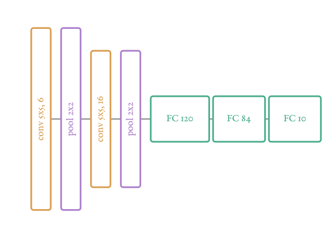

LeNet-5 (LeCun et al., 1989): zip-code digit recognition.

- Convolutions interleaved with downsampling: spatial support grows as layers progress, channel count grows to keep discriminative information
- At the end: a single “pixel” with many channels, then an MLP-like head takes over

## AlexNet & VGG

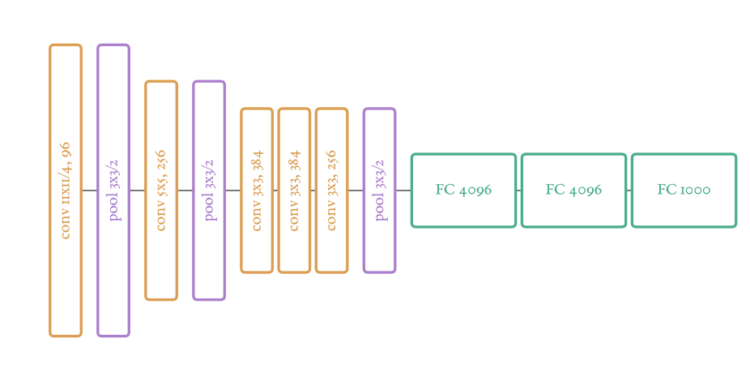

AlexNet (Krizhevsky et al., 2012): ImageNet 2012 winner, 60M parameters.

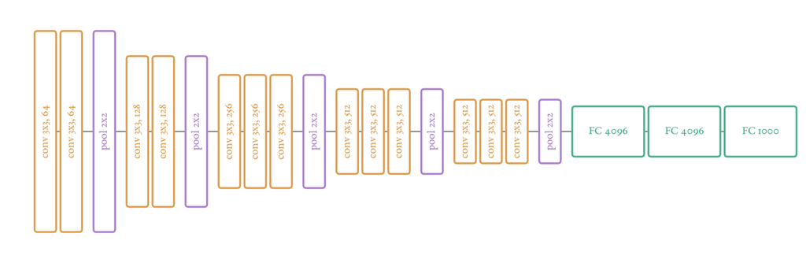

VGG-16: the first CNN beating AlexNet reproducibly, more layers, smaller filters.

- AlexNet: same LeNet principle, scaled to GPU limits. Halted a decade of hand-crafted visual features
- VGG: reproducible (Matconvnet), but beyond its depth, vanishing gradients made training unreliable without *baby-sitting* (checkpoints, manual LR drops)

# ResNet & Residual Connections

2:40–2:55 · 15 min

## ResNet: residual connections

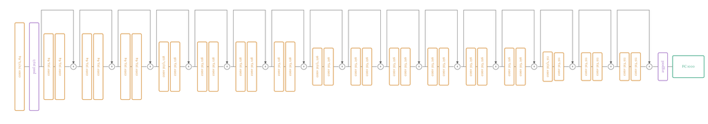

ResNet-34 (He et al., 2016): each “+” is a residual shortcut added back into the main path.

$$x_{l+1} = h_l(x_l) + x_l$$

- Learn a **residual**
- Gradient is **identity plus the layer’s own derivative** → never vanishes
- Most important architectural idea in modern deep learning

# Wrap-up

2:55–3:00 · 5 min

## Recap

- Formal neuron, perceptron: a historical and literal logic-circuit view of what a single unit computes, and how it was first “trained” by hand
- Impossibility theorem: one hyperplane is not enough; MLPs fix this by stacking, at the cost of losing a closed form and needing backprop
- Backprop: the chain rule, reusing each layer’s local gradient exactly once, going backward. Vanishing/exploding gradients are a structural weakness
- CNNs: translation equivariance via weight sharing, from LeNet’s principles to AlexNet’s scale
- ResNet: residual connections, which fix both the optimization *and* the geometry of the loss